# Data manipulation in R 5: Data frame management

Nick Green, Kennesaw State University

December 2, 2021

# 1 Overview

Most of the time when you work with data in R, those data will be stored in **data frames**. A data frame looks like a matrix, but functions in many ways spreadsheet. Internally, a data frame is really a list, but for most day-to-day use you can think of a data frame as a table.

*Being able to manage data frames is an important part of working with R*. This page demonstrates some of the most common data frame operations.

# 2 Data frame structure

Data frames and matrices look very similar, but their internal structures are very different. This has huge implications for how you work with and manipulate data frames and matrices. The figure below shows some of the most important differences.

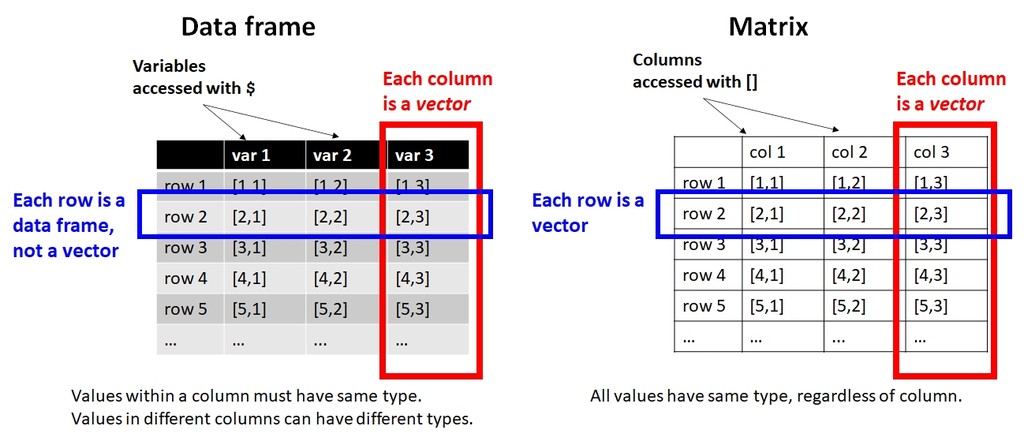

All pieces of a matrix are accessed using [bracket notation](https://greenquanteco.github.io/03-manip-03-brackets.html) (`[]`). Pieces of a data frame can also be accessed using brackets, but the dollar sign `$` can be used to access columns.

```r
# single variables (columns): $
iris$Petal.Length
```

```
##   [1] 1.4 1.4 1.3 1.5 1.4 1.7 1.4 1.5 1.4 1.5 1.5 1.6 1.4 1.1 1.2 1.5 1.3 1.4
##  [19] 1.7 1.5 1.7 1.5 1.0 1.7 1.9 1.6 1.6 1.5 1.4 1.6 1.6 1.5 1.5 1.4 1.5 1.2
##  [37] 1.3 1.4 1.3 1.5 1.3 1.3 1.3 1.6 1.9 1.4 1.6 1.4 1.5 1.4 4.7 4.5 4.9 4.0
##  [55] 4.6 4.5 4.7 3.3 4.6 3.9 3.5 4.2 4.0 4.7 3.6 4.4 4.5 4.1 4.5 3.9 4.8 4.0
##  [73] 4.9 4.7 4.3 4.4 4.8 5.0 4.5 3.5 3.8 3.7 3.9 5.1 4.5 4.5 4.7 4.4 4.1 4.0
##  [91] 4.4 4.6 4.0 3.3 4.2 4.2 4.2 4.3 3.0 4.1 6.0 5.1 5.9 5.6 5.8 6.6 4.5 6.3
## [109] 5.8 6.1 5.1 5.3 5.5 5.0 5.1 5.3 5.5 6.7 6.9 5.0 5.7 4.9 6.7 4.9 5.7 6.0
## [127] 4.8 4.9 5.6 5.8 6.1 6.4 5.6 5.1 5.6 6.1 5.6 5.5 4.8 5.4 5.6 5.1 5.1 5.9
## [145] 5.7 5.2 5.0 5.2 5.4 5.1
```

```r
# multiple variables: brackets []
iris[,c("Petal.Length", "Sepal.Length")]
```

```
##     Petal.Length Sepal.Length
## 1            1.4          5.1
## 2            1.4          4.9
## 3            1.3          4.7
## 4            1.5          4.6
## 5            1.4          5.0
## 6            1.7          5.4
## 7            1.4          4.6
## 8            1.5          5.0
## 9            1.4          4.4
## 10           1.5          4.9
## 11           1.5          5.4
## 12           1.6          4.8
## 13           1.4          4.8
## 14           1.1          4.3
```

[output cut: 136 more lines]

```r
# rows: brackets []
iris[1:4,]
```

```
##   Sepal.Length Sepal.Width Petal.Length Petal.Width Species
## 1          5.1         3.5          1.4         0.2  setosa
## 2          4.9         3.0          1.4         0.2  setosa
## 3          4.7         3.2          1.3         0.2  setosa
## 4          4.6         3.1          1.5         0.2  setosa
```

```r
iris[1,]
```

```
##   Sepal.Length Sepal.Width Petal.Length Petal.Width Species
## 1          5.1         3.5          1.4         0.2  setosa
```

Notice that the syntax for accessing a data frame with `[]` is the same as for accessing a matrix.

When a data frame is printed to the console, this is only a representation of the data frame’s true form: a **list**. This is why single columns are accessible by a `$`: this is the symbol for accessing an element of a list. The list nature of a data frame is also why **rows** of a dataset are actually data frames themselves and not vectors.

# 3 Common data frame operations

## 3.1 Adding and deleting variables

New variables can be added to a data frame by **assignment** (`<-`). Assigning values to a variable in a data frame will create that variable if it doesn’t already exist–and overwrite values if the variable is already in the data frame.

```r
x <- iris[1:5,] # spare copy for demonstration
x$Petal.Area <- apply(x[,3:4], 1, prod)

# shows new variable:
x
```

```
##   Sepal.Length Sepal.Width Petal.Length Petal.Width Species Petal.Area
## 1          5.1         3.5          1.4         0.2  setosa       0.28
## 2          4.9         3.0          1.4         0.2  setosa       0.28
## 3          4.7         3.2          1.3         0.2  setosa       0.26
## 4          4.6         3.1          1.5         0.2  setosa       0.30
## 5          5.0         3.6          1.4         0.2  setosa       0.28
```

```r
# shows variable overwritten:
x$Petal.Area <- 3
x
```

```
##   Sepal.Length Sepal.Width Petal.Length Petal.Width Species Petal.Area
## 1          5.1         3.5          1.4         0.2  setosa          3
## 2          4.9         3.0          1.4         0.2  setosa          3
## 3          4.7         3.2          1.3         0.2  setosa          3
## 4          4.6         3.1          1.5         0.2  setosa          3
## 5          5.0         3.6          1.4         0.2  setosa          3
```

Variables can also be added using function `cbind()`. This name is short for “column bind”[^1]. To use `cbind()`, the input data frames must have the same number of rows. Note that `cbind()` sticks the data frames together as they are. If the records in the inputs need to be matched up and are not already in the same order, then either the data frames need to be aligned, merged with function `merge()`, or the variables need to be added using `match()` and a key variable.

```r
x <- iris[1:5, 1:2]
y <- iris[1:5, 3:5]
cbind(x,y)
```

```
##   Sepal.Length Sepal.Width Petal.Length Petal.Width Species
## 1          5.1         3.5          1.4         0.2  setosa
## 2          4.9         3.0          1.4         0.2  setosa
## 3          4.7         3.2          1.3         0.2  setosa
## 4          4.6         3.1          1.5         0.2  setosa
## 5          5.0         3.6          1.4         0.2  setosa
```

```r
# shows that cbind() uses inputs as-is
cbind(x, y[5:1,])
```

```
##   Sepal.Length Sepal.Width Petal.Length Petal.Width Species
## 1          5.1         3.5          1.4         0.2  setosa
## 2          4.9         3.0          1.5         0.2  setosa
## 3          4.7         3.2          1.3         0.2  setosa
## 4          4.6         3.1          1.4         0.2  setosa
## 5          5.0         3.6          1.4         0.2  setosa
```

Variables can be deleted by setting them to `NULL` (notice all caps) or by making a new version of the data frame without the variable. If I am only removing a few variables, I prefer setting them individually to NULL. This makes it less likely that I will accidentally remove the wrong columns.

```r
x$Petal.Area <- NULL
x
```

```
##   Sepal.Length Sepal.Width
## 1          5.1         3.5
## 2          4.9         3.0
## 3          4.7         3.2
## 4          4.6         3.1
## 5          5.0         3.6
```

```r
# delete 1 variable:
x <- x[,which(names(x) != "Petal.Area")]
x
```

```
##   Sepal.Length Sepal.Width
## 1          5.1         3.5
## 2          4.9         3.0
## 3          4.7         3.2
## 4          4.6         3.1
## 5          5.0         3.6
```

```r
# delete >1 variable
x <- x[,which(!names(x) %in% c("Petal.Area", "Petal.Length"))]
x
```

```
##   Sepal.Length Sepal.Width
## 1          5.1         3.5
## 2          4.9         3.0
## 3          4.7         3.2
## 4          4.6         3.1
## 5          5.0         3.6
```

## 3.2 Modifying variables

Variables can be modified by assigning them their new values. Note that this overwrites the previous values. If you think you might want the old values for some reason, save the modified values in a new variable instead.

```r
x <- iris[1:5,] # spare copy for demonstration
x$Petal.Length <- log(x$Petal.Length)

# better: keep modified values in new variable
x <- iris[1:10,] # spare copy for demonstration
x$log.petlen <- log(x$Petal.Length)
```

## 3.3 Changing values in a variable using a rule

By combining the methods for [data selection](https://greenquanteco.github.io/03-manip-03-brackets.html) and assignment, values in a variable can be replaced according to their values.

```r
# not run (long output):
x <- iris

# select and replace by one condition:
flag <- which(x$Sepal.Length >= 6)
x$Sepal.Length[flag] <- 5.99

# select and replace by 2 conditions:
flag1 <- which(x$Petal.Length >= 3)
flag2 <- which(x$Petal.Length <= 5)
x$Petal.Length[intersect(flag1, flag2)] <- 4
```

## 3.4 Renaming variables

Renaming variables in Excel is easy: just enter the new name into the cell at the top of a column. Things are a little more complicated in R but not much.

One way is to use the **data frame editor**. Use the `edit()` function to open the data editor, a spreadsheet-like interface for working with data frames. Then click on the column name and enter the new name (and then press ENTER). You can also edit individual values this way, but I don’t recommend this method for routine use because there is no record in your script of what was done.

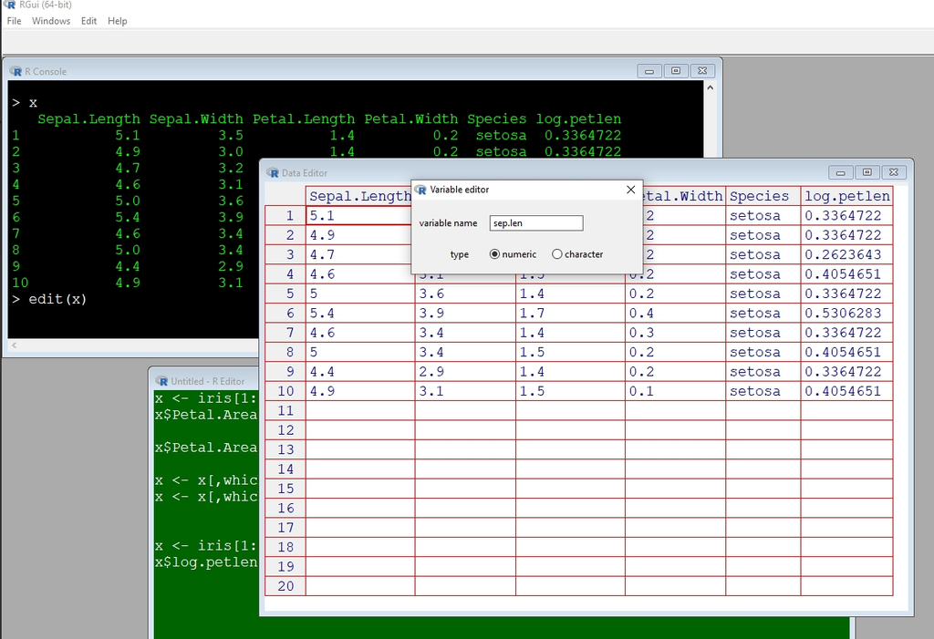

The better way is to rename the variable using R code. There are a few ways to do this, but they all involve accessing the variable names using function `names()`.

```r
x <- iris[1:5,] # spare copy for demonstration

# by column number:
names(x)[1] <- "sep.len"
x
```

```
##   sep.len Sepal.Width Petal.Length Petal.Width Species
## 1     5.1         3.5          1.4         0.2  setosa
## 2     4.9         3.0          1.4         0.2  setosa
## 3     4.7         3.2          1.3         0.2  setosa
## 4     4.6         3.1          1.5         0.2  setosa
## 5     5.0         3.6          1.4         0.2  setosa
```

```r
# match name exactly:
names(x)[which(names(x) == "Petal.Length")] <- "pet.len"
x
```

```
##   sep.len Sepal.Width pet.len Petal.Width Species
## 1     5.1         3.5     1.4         0.2  setosa
## 2     4.9         3.0     1.4         0.2  setosa
## 3     4.7         3.2     1.3         0.2  setosa
## 4     4.6         3.1     1.5         0.2  setosa
## 5     5.0         3.6     1.4         0.2  setosa
```

```r
# by position:
names(x)[ncol(x)] <- "species"
x
```

```
##   sep.len Sepal.Width pet.len Petal.Width species
## 1     5.1         3.5     1.4         0.2  setosa
## 2     4.9         3.0     1.4         0.2  setosa
## 3     4.7         3.2     1.3         0.2  setosa
## 4     4.6         3.1     1.5         0.2  setosa
## 5     5.0         3.6     1.4         0.2  setosa
```

```r
names(x)[1] <- "petal.len"
x
```

```
##   petal.len Sepal.Width pet.len Petal.Width species
## 1       5.1         3.5     1.4         0.2  setosa
## 2       4.9         3.0     1.4         0.2  setosa
## 3       4.7         3.2     1.3         0.2  setosa
## 4       4.6         3.1     1.5         0.2  setosa
## 5       5.0         3.6     1.4         0.2  setosa
```

```r
# change several names at once:
names(x)[1:4] <- paste0("x", 1:4)
x
```

```
##    x1  x2  x3  x4 species
## 1 5.1 3.5 1.4 0.2  setosa
## 2 4.9 3.0 1.4 0.2  setosa
## 3 4.7 3.2 1.3 0.2  setosa
## 4 4.6 3.1 1.5 0.2  setosa
## 5 5.0 3.6 1.4 0.2  setosa
```

Finally, you can make a new copy of the variable with the name you want, then delete the original version. This has the disadvantage of changing the order of columns.

```r
x <- iris[1:5,] # spare copy for demonstration
x$pet.len <- x$Petal.Length
x$Petal.Length <- NULL
x
```

```
##   Sepal.Length Sepal.Width Petal.Width Species pet.len
## 1          5.1         3.5         0.2  setosa     1.4
## 2          4.9         3.0         0.2  setosa     1.4
## 3          4.7         3.2         0.2  setosa     1.3
## 4          4.6         3.1         0.2  setosa     1.5
## 5          5.0         3.6         0.2  setosa     1.4
```

## 3.5 Rearranging columns

Reordering records or columns within a data frame is accomplished by creating a new version of the dataset with the desired arrangement. This rearrangement is accomplished using methods we have already seen.

```r
x <- iris[1:5,]

# rearrange by number
x <- x[,c(5, 3, 4, 1, 2)]
x
```

```
##   Species Petal.Length Petal.Width Sepal.Length Sepal.Width
## 1  setosa          1.4         0.2          5.1         3.5
## 2  setosa          1.4         0.2          4.9         3.0
## 3  setosa          1.3         0.2          4.7         3.2
## 4  setosa          1.5         0.2          4.6         3.1
## 5  setosa          1.4         0.2          5.0         3.6
```

```r
# rearrange by name
col.order <- c("Species", "Sepal.Length", "Sepal.Width",
               "Petal.Length", "Petal.Width")
x <- x[,col.order]
x
```

```
##   Species Sepal.Length Sepal.Width Petal.Length Petal.Width
## 1  setosa          5.1         3.5          1.4         0.2
## 2  setosa          4.9         3.0          1.4         0.2
## 3  setosa          4.7         3.2          1.3         0.2
## 4  setosa          4.6         3.1          1.5         0.2
## 5  setosa          5.0         3.6          1.4         0.2
```

## 3.6 Sorting and ordering data

Sorting data frames is mostly done using the function `order()`. This function is usually put inside brackets in the rows slot. The arguments to `order()` define the variables by which the data frame will be sorted. Rows are sorted by the first variable, then the second, and so on. By default, rows are placed in *ascending* order.

```r
# not run (long output):
DNase
DNase[order(DNase$conc),]
iris
iris[order(iris$Species, iris$Petal.Length),]
```

You can multiple variables to `order()`, by name, and R will order the rows in each variable in the order supplied. By default, records are sorted in ascending order. If you want a mix of ascending and descending order, you have to specify the `radix` method and specify whether you want the order to be decreasing (TRUE) or not (FALSE) for each variable:

```r
# not run (long output):

iris[order(iris$Species, iris$Petal.Length,
           decreasing=c(TRUE, FALSE),
           method="radix"),]

iris[order(iris$Species, iris$Petal.Length,
           decreasing=c(TRUE, TRUE),
           method="radix"),]
```

## 3.7 Adding or removing rows

Removing rows works a lot like removing columns. You can use the bracket notation to either remove the rows with negative indices, or make a new version of the data frame with only some of the rows.

```r
x <- iris[1:10,]

# remove by row number
x[-1,]
```

```
##    Sepal.Length Sepal.Width Petal.Length Petal.Width Species
## 2           4.9         3.0          1.4         0.2  setosa
## 3           4.7         3.2          1.3         0.2  setosa
## 4           4.6         3.1          1.5         0.2  setosa
## 5           5.0         3.6          1.4         0.2  setosa
## 6           5.4         3.9          1.7         0.4  setosa
## 7           4.6         3.4          1.4         0.3  setosa
## 8           5.0         3.4          1.5         0.2  setosa
## 9           4.4         2.9          1.4         0.2  setosa
## 10          4.9         3.1          1.5         0.1  setosa
```

```r
x[-c(1:3),]
```

```
##    Sepal.Length Sepal.Width Petal.Length Petal.Width Species
## 4           4.6         3.1          1.5         0.2  setosa
## 5           5.0         3.6          1.4         0.2  setosa
## 6           5.4         3.9          1.7         0.4  setosa
## 7           4.6         3.4          1.4         0.3  setosa
## 8           5.0         3.4          1.5         0.2  setosa
## 9           4.4         2.9          1.4         0.2  setosa
## 10          4.9         3.1          1.5         0.1  setosa
```

```r
x[-c(1, 3, 5, 7, 9),]
```

```
##    Sepal.Length Sepal.Width Petal.Length Petal.Width Species
## 2           4.9         3.0          1.4         0.2  setosa
## 4           4.6         3.1          1.5         0.2  setosa
## 6           5.4         3.9          1.7         0.4  setosa
## 8           5.0         3.4          1.5         0.2  setosa
## 10          4.9         3.1          1.5         0.1  setosa
```

```r
# or, make a new copy with the
# rows to keep
x[2:10,]
```

```
##    Sepal.Length Sepal.Width Petal.Length Petal.Width Species
## 2           4.9         3.0          1.4         0.2  setosa
## 3           4.7         3.2          1.3         0.2  setosa
## 4           4.6         3.1          1.5         0.2  setosa
## 5           5.0         3.6          1.4         0.2  setosa
## 6           5.4         3.9          1.7         0.4  setosa
## 7           4.6         3.4          1.4         0.3  setosa
## 8           5.0         3.4          1.5         0.2  setosa
## 9           4.4         2.9          1.4         0.2  setosa
## 10          4.9         3.1          1.5         0.1  setosa
```

```r
x[c(2, 4, 6, 8, 10),]
```

```
##    Sepal.Length Sepal.Width Petal.Length Petal.Width Species
## 2           4.9         3.0          1.4         0.2  setosa
## 4           4.6         3.1          1.5         0.2  setosa
## 6           5.4         3.9          1.7         0.4  setosa
## 8           5.0         3.4          1.5         0.2  setosa
## 10          4.9         3.1          1.5         0.1  setosa
```

Adding rows can be done with `rbind()` (short for “row bind”). This function is analogous to `cbind()`, which joins objects by their columns. Adding rows to a data frame is tantamount to combining it with another data frame. The data frames being combined must have the same columns, with the same names, but the order of columns can be different.

```r
x <- iris[1:10,]
y <- iris[15:20,]

# columns match exactly:
rbind(x, y)
```

```
##    Sepal.Length Sepal.Width Petal.Length Petal.Width Species
## 1           5.1         3.5          1.4         0.2  setosa
## 2           4.9         3.0          1.4         0.2  setosa
## 3           4.7         3.2          1.3         0.2  setosa
## 4           4.6         3.1          1.5         0.2  setosa
## 5           5.0         3.6          1.4         0.2  setosa
## 6           5.4         3.9          1.7         0.4  setosa
## 7           4.6         3.4          1.4         0.3  setosa
## 8           5.0         3.4          1.5         0.2  setosa
## 9           4.4         2.9          1.4         0.2  setosa
## 10          4.9         3.1          1.5         0.1  setosa
## 15          5.8         4.0          1.2         0.2  setosa
## 16          5.7         4.4          1.5         0.4  setosa
## 17          5.4         3.9          1.3         0.4  setosa
## 18          5.1         3.5          1.4         0.3  setosa
## 19          5.7         3.8          1.7         0.3  setosa
## 20          5.1         3.8          1.5         0.3  setosa
```

```r
# columns in different order:
y2 <- y[,c(3,5,2,1,4)]
rbind(x,y2)
```

```
##    Sepal.Length Sepal.Width Petal.Length Petal.Width Species
## 1           5.1         3.5          1.4         0.2  setosa
## 2           4.9         3.0          1.4         0.2  setosa
## 3           4.7         3.2          1.3         0.2  setosa
## 4           4.6         3.1          1.5         0.2  setosa
## 5           5.0         3.6          1.4         0.2  setosa
## 6           5.4         3.9          1.7         0.4  setosa
## 7           4.6         3.4          1.4         0.3  setosa
## 8           5.0         3.4          1.5         0.2  setosa
## 9           4.4         2.9          1.4         0.2  setosa
## 10          4.9         3.1          1.5         0.1  setosa
## 15          5.8         4.0          1.2         0.2  setosa
## 16          5.7         4.4          1.5         0.4  setosa
## 17          5.4         3.9          1.3         0.4  setosa
## 18          5.1         3.5          1.4         0.3  setosa
## 19          5.7         3.8          1.7         0.3  setosa
## 20          5.1         3.8          1.5         0.3  setosa
```

```r
# result inherits order of columns from first argument:
rbind(y2,x)
```

```
##    Petal.Length Species Sepal.Width Sepal.Length Petal.Width
## 15          1.2  setosa         4.0          5.8         0.2
## 16          1.5  setosa         4.4          5.7         0.4
## 17          1.3  setosa         3.9          5.4         0.4
## 18          1.4  setosa         3.5          5.1         0.3
## 19          1.7  setosa         3.8          5.7         0.3
## 20          1.5  setosa         3.8          5.1         0.3
## 1           1.4  setosa         3.5          5.1         0.2
## 2           1.4  setosa         3.0          4.9         0.2
## 3           1.3  setosa         3.2          4.7         0.2
## 4           1.5  setosa         3.1          4.6         0.2
## 5           1.4  setosa         3.6          5.0         0.2
## 6           1.7  setosa         3.9          5.4         0.4
## 7           1.4  setosa         3.4          4.6         0.3
## 8           1.5  setosa         3.4          5.0         0.2
## 9           1.4  setosa         2.9          4.4         0.2
## 10          1.5  setosa         3.1          4.9         0.1
```

# 4 Other data frame operations

## 4.1 Merging datasets

Data sets for a complex project might reside in several tables, related by **key variables**. These are variables that are shared by more than one table, and define which records in each table are related to records in another table. This is exactly what relational databases do, but most biologists have small enough datasets that databases aren’t necessary.

Data frames can be combined by manually matching records between tables, using the function `match()`. The example below uses three interrelated tables from a stream dataset I work with. You need the datasets dat_samples_2021-08-04.csv, dat_stream_indices_2021-08-04.csv, and loc_meta_vaa_2020-11-18.csv. Download them and put them in your R home directory.

```r
options(stringsAsFactors=FALSE)

# data file names
name1 <- "dat_samples_2021-08-04.csv"
name2 <- "dat_stream_indices_2021-08-04.csv"
name3 <- "loc_meta_vaa_2020-11-18.csv"

# import
x1 <- read.csv(name1, header=TRUE)
x2 <- read.csv(name2, header=TRUE)
x3 <- read.csv(name3, header=TRUE)

# notice that the tables have only "key" variables
# in common, and tables don't necessarily share any
# variables with every other table
intersect(names(x1), names(x2))
```

```
## [1] "uocc"
```

```r
intersect(names(x1), names(x3))
```

```
## [1] "loc"
```

```r
intersect(names(x2), names(x3))
```

```
## character(0)
```

```r
# x2 contains the response variable, so
# use it to build main dataset "dat"
dat <- x2

# add site name, year, and date from x1
# by matching unique occasion (uocc) from
# dat to metadata table x1
matchx <- match(dat$uocc, x1$uocc)
dat$site <- x1$loc[matchx]
dat$year <- x1$year[matchx]
dat$doy  <- x1$doy[matchx]

# dat now has site, which allows it to be
# related to the geographic metadata x3.
# grab latitude and longitude from x3
matchx <- match(dat$site, x3$loc)
dat$lat <- x3$lat[matchx]
dat$long <- x3$long[matchx]
```

Matching many variables by hand can become very tedious and error-prone. An alternative, and usually faster way is the function `merge()`. This is a shortcut for the matching that we did manually above. The downside of using `merge()` is that it can be a little obtuse–`merge()` will attempt to match records exactly, which may or may not return the results you expect. Using `merge()` can also sometimes result in many duplicate columns or extra rows in the result. Always inspect the results of `merge()` to make sure it is doing what you expect (i.e., that you wrote the code correctly to get what you wanted!).

The commands below duplicate the merging done piecemeal above.

```r
# x2 contains the response variable
dat <- x2

# merge by the variables in common:
dat2 <- merge(dat, x1)
dat3 <- merge(dat2, x3)
head(dat3)
```

```
##           loc    uocc      ind year doy      lat      long         basin
## 1 RV_01_16345 occ_001 48.40576 2017  54 34.05400 -83.24100 Savannah (01)
## 2   RV_01_240 occ_002 56.78960 2006  25 32.67461 -81.46906 Savannah (01)
## 3   RV_01_241 occ_003 60.06336 2003  33 33.58468 -82.65235 Savannah (01)
## 4   RV_01_242 occ_004 21.30232 2002 292 33.38387 -82.00422 Savannah (01)
## 5   RV_01_243 occ_005 51.50136 2002  12 33.83757 -82.91251 Savannah (01)
## 6   RV_01_244 occ_006 73.91343 2007  16 34.95895 -83.57158 Savannah (01)
##         huc12   state   county             ecoregion3 ecoregion4
## 1 30601040402 Georgia  Madison               Piedmont        45b
## 2 30601090104 Georgia  Screven Southern Coastal Plain        75f
## 3 30601050203 Georgia   Warren               Piedmont        45c
## 4 30601060602 Georgia Richmond    Southeastern Plains        65c
## 5 30601040504 Georgia   Wilkes               Piedmont        45c
## 6 30601020101 Georgia    Towns             Blue Ridge        66d
##                                       eco4 gridcode catchkm2      fid      bfi
## 1                  Southern Outer Piedmont  2331987   2.3616  6278849 59.00000
## 2                     Sea Island Flatwoods  2339456  12.5667 20103925 57.01117
## 3                      Carolina Slate Belt  2334311  11.7000  6289897 44.00000
## 4                               Sand Hills  2335367   1.8666 22725381 63.94214
## 5                      Carolina Slate Belt  2331832  13.6170  6280051 50.75585
## 6 Southern Crystaline Ridges and Mountains  2328238   4.6449  6267588 64.17283
##        elev  roaddens storder        flow      slope   huc08 fish.rich
## 1 206.97063 2.4394053       3 -0.24495427 0.00001000 3060104        35
## 2  28.11548 2.1069683       3 -0.23087494 0.00176311 3060109        61
## 3 142.94652 1.6804648       1 -0.81467829 0.00877661 3060105        21
## 4  55.97662 3.4675126       3 -0.03230713 0.00055628 3060106        83
## 5 166.52806 1.5691058       1 -0.72841189 0.00605539 3060104        35
## 6 925.20189 0.3386832       1 -0.52734597 0.03813850 3060102        51
```

```r
# what if you only want some variables to be merged?
x3.cols <- c("loc", "lat", "long")
dat4 <- merge(x2, x1)
dat4 <- merge(dat4, x3[,x3.cols])
head(dat4)
```

```
##           loc    uocc      ind year doy      lat      long
## 1 RV_01_16345 occ_001 48.40576 2017  54 34.05400 -83.24100
## 2   RV_01_240 occ_002 56.78960 2006  25 32.67461 -81.46906
## 3   RV_01_241 occ_003 60.06336 2003  33 33.58468 -82.65235
## 4   RV_01_242 occ_004 21.30232 2002 292 33.38387 -82.00422
## 5   RV_01_243 occ_005 51.50136 2002  12 33.83757 -82.91251
## 6   RV_01_244 occ_006 73.91343 2007  16 34.95895 -83.57158
```

Some of the tidyverse packages offer alternative solutions for merging datasets that can be more or less elegant than `merge()`. However, the methods shown above use only base R functions and will get the job done.

## 4.2 Reshaping data

In your career you are likely to encounter datasets organized in a variety of formats. Most of these formats fall into one of two categories: **wide** and **long**.

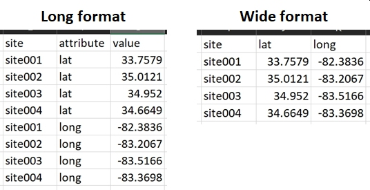

In a **long-format dataset**, every value is stored in a separate *row*. The variable (AKA: feature or attribute), that each value represents is kept in a separate *column*. Many public or online data sources serve datasets in long format. This is usually because the data are pulled from a database, and it left to the user to reshape the data to fit their needs. Storing data in this manner can sometimes be more efficient from a computational standpoint, but it is usually not convenient for analysis. The reason that long format is inconvenient for analysis is because all of the information about individual samples (i.e, observations) are on different rows of the dataset.

In a **wide-format dataset**, each row contains **all values** associated with a particular **sample**. This means that each variable gets its own column, and each cell contains a single value. This format is sometimes called **tidy** format by the authors of the `tidyverse` set of R packages (Wickham 2014), but researchers were formatting data this way long before the tidyverse packages or R were developed (Broman and Woo 2018). As a rule, you should store and manage your data in wide/tidy format. This format makes it easy to take advantage of R’s vectorized nature.

Base R has some functions for reshaping data, but most sources recommend using the `reshape2` package or the `tidyverse`. The examples below demonstrate reshaping a dataset from a typical long format to a more useful wide format. You will need the file reshape_example.csv in your R home directory and package `reshape2`.

```r
options(stringsAsFactors=FALSE)
library(reshape2)
in.name <- "reshape_example.csv"
x <- read.csv(in.name)
head(x)
```

```
##        site  attribute      value
## 1 RV_01_245        lat  33.757913
## 2 RV_01_245       long -82.383578
## 3 RV_01_245   catchkm2     11.079
## 4 RV_01_245 ecoregion3   Piedmont
## 5 RV_01_248        lat  34.952033
## 6 RV_01_248       long -83.516598
```

```r
class(x$value)
```

```
## [1] "character"
```

Notice that the `value` column contains a mix of numeric and text values. This means that the numbers are stored as text. If we wanted to do something with those values, they need to be pulled out of the vector `value` and converted to numeric values. Because a vector can have only one type of value, the attributes will need to end up in their own columns. The fastest way to do this is to use the function `dcast()` from package `reshape2`.

```r
dx <- dcast(x, site~attribute)
dx$catchkm2 <- as.numeric(dx$catchkm2)
dx$lat <- as.numeric(dx$lat)
dx$long <- as.numeric(dx$long)
head(dx)
```

```
##        site catchkm2 ecoregion3      lat      long
## 1 RV_01_245  11.0790   Piedmont 33.75791 -82.38358
## 2 RV_01_248   7.5924 Blue Ridge 34.95203 -83.51660
## 3 RV_01_250   0.6165 Blue Ridge 34.66491 -83.36978
## 4 RV_01_253   2.5614   Piedmont 33.84107 -82.95028
## 5 RV_01_255   7.8687   Piedmont 33.75356 -82.54828
## 6 RV_01_257   1.9629   Piedmont 33.66435 -82.55340
```

If we needed to go the other way, from wide to long format, we use function `melt()`. This is essentially the reverse of `dcast()`.

```r
mx <- melt(dx,
           id.vars="site",
           measure.vars=c("lat", "long", "catchkm2", "ecoregion3"))
head(mx)
```

```
##        site variable     value
## 1 RV_01_245      lat 33.757913
## 2 RV_01_248      lat 34.952033
## 3 RV_01_250      lat 34.664911
## 4 RV_01_253      lat 33.841068
## 5 RV_01_255      lat 33.753558
## 6 RV_01_257      lat 33.664353
```

```r
head(mx[order(mx$site, mx$variable),])
```

```
##         site   variable      value
## 1  RV_01_245        lat  33.757913
## 11 RV_01_245       long -82.383578
## 21 RV_01_245   catchkm2     11.079
## 31 RV_01_245 ecoregion3   Piedmont
## 2  RV_01_248        lat  34.952033
## 12 RV_01_248       long -83.516598
```

The `tidyverse` equivalents for `melt()` and `dcast()` are `pivot_longer()` and `pivot_wider()`, respectively. The syntax of these `tidyverse` functions are similar to the `reshape2` functions. Note that the `tidyverse` functions will output a **tibble**, which is a form of data frame peculiar to the `tidyverse`. Some non-`tidyverse` functions can use tibbles, and some cannot. Tibbles can be converted to base R data frames with function `data.frame()`.

```r
library(tidyr)
tdx <- pivot_wider(x,
                   names_from="attribute",
                   values_from="value")
head(tdx)
```

```
## # A tibble: 6 x 5
##   site      lat       long       catchkm2 ecoregion3
##   <chr>     <chr>     <chr>      <chr>    <chr>
## 1 RV_01_245 33.757913 -82.383578 11.079   Piedmont
## 2 RV_01_248 34.952033 -83.516598 7.5924   Blue Ridge
## 3 RV_01_250 34.664911 -83.369779 0.6165   Blue Ridge
## 4 RV_01_253 33.841068 -82.95028  2.5614   Piedmont
## 5 RV_01_255 33.753558 -82.548275 7.8687   Piedmont
## 6 RV_01_257 33.664353 -82.553397 1.9629   Piedmont
```

```r
tmx <- pivot_longer(tdx,
               cols=c("lat", "long", "catchkm2", "ecoregion3"),
               names_to="variable")
head(tmx)
```

```
## # A tibble: 6 x 3
##   site      variable   value
##   <chr>     <chr>      <chr>
## 1 RV_01_245 lat        33.757913
## 2 RV_01_245 long       -82.383578
## 3 RV_01_245 catchkm2   11.079
## 4 RV_01_245 ecoregion3 Piedmont
## 5 RV_01_248 lat        34.952033
## 6 RV_01_248 long       -83.516598
```

```r
# if needed:
tdx.df <- data.frame(tdx)
```

[**Go back to main page**](https://greenquanteco.github.io/index.html)

# 5 References

Broman, K. W., and K. H. Woo. 2018. [Data organization in spreadsheets](https://doi.org/10.1080/00031305.2017.1375989). The American Statistician 72:2–10.

Wickham, H. 2014. [Tidy data](https://doi.org/10.18637/jss.v059.i10). Journal of Statistical Software 59.

# 6 Legal notice

This site is for educational purposes only. This work and its content is released under the [Creative Commons Attribution-ShareAlike 4.0](https://creativecommons.org/licenses/by-sa/4.0/) license. Inclusion of third-party data falls under guidelines of fair use as defined in [section 107 of the US Copyright Act of 1976](https://www.law.cornell.edu/uscode/text/17/107).

[^1]: `cbind()` also works on matrices.